# Week 6, day 3

Homework

```r
library(tidyverse)
library(janitor)
library(infer)
ames <- clean_names(read_csv("data/ames.csv"))
```

# Task 2

Investigate the distribution of lot_area. Is the distribution roughly normal? If not, what problems do you find?

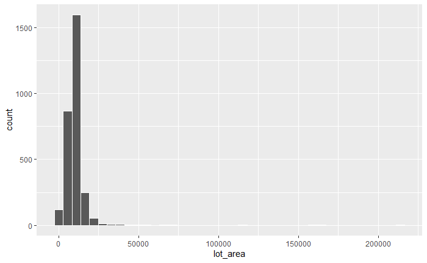

```r
ames %>%
  ggplot(aes(lot_area)) +
  geom_histogram(colour = "white", bins = 40)
```

There appears to be data at very high lot areas which skewes the histogram. Otherwise it is fairly close to normal.

# Task 3

Compute and visualise a bootstrap sampling distribution for the mean(lot_area) of the sold houses.

```r
bootstrap_ames <- ames %>%
  specify(response = lot_area) %>%
  generate(reps = 5000, type = "bootstrap") %>%
  calculate(stat = "mean")
```

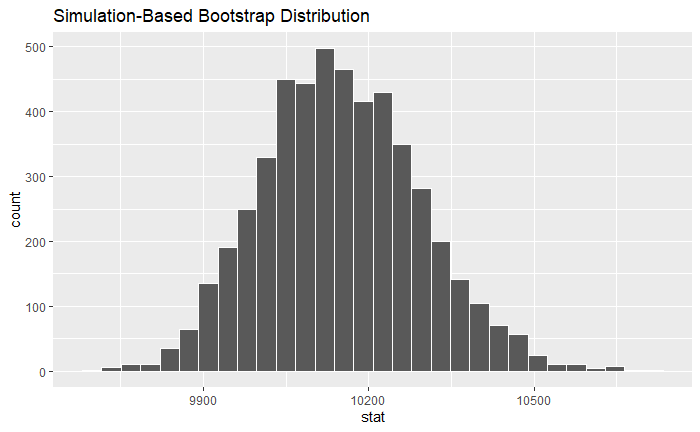

```r
bootstrap_ames %>%
  visualise(bins = 30)
```

# Task 4.

Use your bootstrap distribution to calculate a 95% CI for mean(lot_area), and visualise it on the distribution

```r
ames_ci_95 <- bootstrap_ames %>%
  get_ci(level = 0.95)

ames_ci_95
```

| lower_ci | upper_ci |
| --- | --- |
| 9889.86 | 10447.48 |

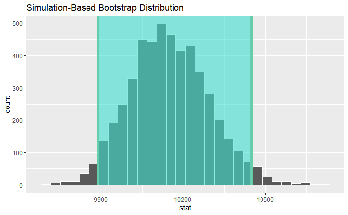

```r
bootstrap_ames %>%
  visualise(bins = 30) +
  shade_ci(ames_ci_95)
```

# Task 5.

You would like to know the mean(lot_area) of the sold houses with higher confidence.  
Calculate the 99% CI for this variable (you can re-use your bootstrap distribution from above).  
Is it narrower or broader than the 95%CI? Does that make sense?

```r
ames_ci_99 <- bootstrap_ames %>%
  get_ci(level = 0.99)

ames_ci_99
```

| lower_ci | upper_ci |
| --- | --- |
| 9808.335 | 10546.17 |

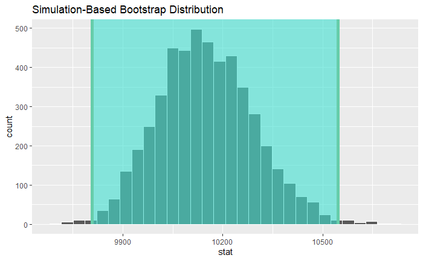

```r
bootstrap_ames %>%
  visualise(bins = 30) +
  shade_ci(ames_ci_99)
```

The 99% CI is broader than the 95% CI. This is as expected.

# Task 6.

Calculate the point estimate of the mean(lot_area)

```r
ames %>%
  summarise(mean = mean(lot_area))
```

| mean |
| --- |
| 10147.92 |

# Conclusion

# Extension

Calculate a point estimate and 95% CI for the proportion of houses in the data built before 1920. Does the number of reps you use matter?

```r
built_before_ames_200
```

```
Response: built_before_1920 (factor)
```

| replicate | stat |
| --- | --- |
| 1 | 0.06245734 |
| 2 | 0.06245734 |
| 3 | 0.06348123 |
| 4 | 0.06177474 |
| 5 | 0.05767918 |
| 6 | 0.06928328 |
| 7 | 0.05836177 |
| 8 | 0.06143345 |
| 9 | 0.06279863 |
| 10 | 0.05392491 |

[output cut: 190 more lines]

```r
built_before_ames_200 %>%
  get_ci(level = 0.95)
```

| lower_ci | upper_ci |
| --- | --- |
| 0.05151877 | 0.06860922 |

```r
built_before_ames_200 %>%
  summarise(prop = mean(stat))
```

| prop |
| --- |
| 0.06035495 |

6.0% [5.2%, 6.9%]

```r
built_before_ames_5000 <- ames %>%
  specify(response = built_before_1920, success = "Yes") %>%
  generate(reps = 5000, type = "bootstrap") %>%
  calculate(stat = "prop")
```

```r
built_before_ames_5000 %>%
  get_ci(level = 0.95)
```

| lower_ci | upper_ci |
| --- | --- |
| 0.05187713 | 0.06860068 |

```r
built_before_ames_5000 %>%
  summarise(prop = mean(stat))
```

| prop |
| --- |
| 0.06011727 |

```r
built_before_ames_50000 <- ames %>%
  specify(response = built_before_1920, success = "Yes") %>%
  generate(reps = 50000, type = "bootstrap") %>%
  calculate(stat = "prop")
```

```r
built_before_ames_50000 %>%
  get_ci(level = 0.95)
```

| lower_ci | upper_ci |
| --- | --- |
| 0.05153584 | 0.06860068 |

```r
built_before_ames_50000 %>%
  summarise(prop = mean(stat))
```

| prop |
| --- |
| 0.06007031 |